# Tecnicas de Inferencia

Carlos Grande Nuñez, Veronica Gomez Gomez y Pablo Olmos Martinez,

10/20/2019

# ANALISIS DE TECNICAS DE INFERENCIA.

El objetivo de esta practica es analizar las distintas tecnicas de inferencia usadas en clase. Para esta practica hemos usado el siguiente dataset:

https://www.kaggle.com/mishra5001/credit-card

Las librerias usadas son las siguientes:

- sampling
- normtest
- nortest
- data.table

## Informacion general sobre los datos que vamos a usar

Hemos decidido usar unos datos basados en prestamos bancarios, las columnas y datos con los que contamos son los siguientes:

Variables de tipo discreto:

```
 - Género
 - Flags
 - tipo de casa
 - ORGANIZATION_TYPE
 - OCCUPATION_TYPE
 - NAME_EDUCATION_TYPE
 - NAME_FAMILY_STATUS
 - NAME_HOUSING_TYPE
```

Variables de tipo continuo:

```
 - AMT_INCOME_TOTAL
 - AMT_CREDIT
 - AMT_ANNUITY
 - AMT_GOODS_PRICE
 - edad
 - Antiguedad en el empleo
```

Antes de comenzar con la practica hemos querido analizar nuestra variable Target de la base de datos, la cual nos indica aquellos creditos que han sido pagados con un ‘0’ y los que no lo han sido con un ‘1’.

```r
#contabilizamos el número de elementos de cada clase en la variable 'TARGET'
table(base$TARGET)
```

```
##
##      0      1
## 282686  24825
```

```r
#Obtenemos el porcentaje de cada elemento dentro de 'TARGET'
prop.table(table(base$TARGET))
```

```
##
##          0          1
## 0.91927118 0.08072882
```

Como dato interesante podemos observar que aproximadamente el 8% de los creditos concedidos no son pagados.

## Ejercicio 1: Muestreo del conjunto de datos

Para obtener una muestra de nuestra población, aplicamos la fórmula del tamaño muestral para la media con varianza conocida. Para resolver la fórmula partimos del tamaño poblacional (300k) , un error máximo de 5000 euros y un nivel de confianmza del 95%.

```r
baset <- data.table(base)

#media poblacional (mp)
mp <- mean(baset$AMT_INCOME_TOTAL)
mp
```

```
## [1] 168797.9
```

```r
#desviación estandar (dt)
dt <- sd(baset$AMT_INCOME_TOTAL)
dt
```

```
## [1] 237123.1
```

```r
#busqueda del tamaño muestral optimo
##variables a usar
N <- dim(baset)[1] #poblacion
N
```

```
## [1] 307511
```

```r
err <- 5000
NS <- 0.05
k <- qnorm(1-NS/2);round(k,3)#k=f(z)
```

```
## [1] 1.96
```

```r
s2 <- (dt)^2
D <- err^2/k^2

#formula tamaño muestral para la media con varianza conocida
n <- (N*s2*(k^2))/((err^2)*(N-1) + s2*(k^2))
round(n)
```

```
## [1] 8404
```

Una vez aplicada la fórmula del tamaño muestral obtenemos que para nuestra población necesitamos una muestra de al menos 8404 elementos.

A continuación realizamos el muestreo de datos.

```r
set.seed(1)

#muestreo sobre la población
mas <- baset[sample(.N, 8404)]
#contabilizamos el número de elementos de cada clase en la variable 'TARGET'
table(mas$TARGET)
```

```
##
##    0    1
## 7721  683
```

```r
#Obtenemos el porcentaje de cada elemento dentro de 'TARGET'
prop.table(table(mas$TARGET))
```

```
##
##          0          1
## 0.91872918 0.08127082
```

Mostramos a continuación el encabezado de nuestra tabla muestral con las variables que vamos a usar a lo largo de esta práctica:

```r
head(mas %>% select(CODE_GENDER, NAME_EDUCATION_TYPE, OCCUPATION_TYPE, AMT_INCOME_TOTAL))
```

```
##    CODE_GENDER           NAME_EDUCATION_TYPE       OCCUPATION_TYPE
## 1:           F Secondary / secondary special
## 2:           F Secondary / secondary special
## 3:           F Secondary / secondary special
## 4:           F Secondary / secondary special Private service staff
## 5:           M Secondary / secondary special               Drivers
## 6:           F Secondary / secondary special
##    AMT_INCOME_TOTAL
## 1:            90000
## 2:           202500
## 3:            54000
## 4:           243000
## 5:           135000
## 6:           157500
```

Definimos antes los subsets sobre los que trabajaremos a partir de ahora. Donde t1 (TARGET = 1) corresponde los creditos con impago y t0 (TARGET = 0) corresponde a los creditos pagados

```r
#t1 impago
t1 <- subset(mas, TARGET=="1")
dim(t1)[1]
```

```
## [1] 683
```

```r
#t0 pago
t0 <- subset(mas, TARGET=="0")
dim(t0)[1]
```

```
## [1] 7721
```

## Ejercicio2: Caracteristicas interesantes sujetas a estudio

Hemos encontrado las siguientes caracteristicas como intersantes para el estudio:

- Cuanto es la media del importe de crédito solicitado
- Cuanto es el ingreso medio de los clientes
- ¿Cual es la edad media del cliente que solicita?
- ¿Cual es la media de la antigüedad en la empresa del cliente medio?
- Contrastando con el pago/impago del credito

Para la practica nos centraremos en la característica del ingreso medio de los clientes.

## Ejercicio3: Estimaciones puntuales de la caracteristica

### Estimacion puntual de la media de los ingresos de los clientes

Ingresos de los clientes cliente, Media Poblacion

```r
#media poblacional de los ingresos medios del cliente
media.importe <- mean(baset$AMT_INCOME_TOTAL)
media.importe
```

```
## [1] 168797.9
```

```r
#desviacion estandar de la poblacion de los ingresos medios del cliente
dt.importe <- sd(baset$AMT_INCOME_TOTAL)
dt.importe
```

```
## [1] 237123.1
```

Ingresos de los clientes, Media Muestral

```r
#importe solcitado del cliente Media Muestral
media.importe_mas<-mean(mas$AMT_INCOME_TOTAL)
dt.importe_mas<-sd(mas$AMT_INCOME_TOTAL)
media.importe_mas
```

```
## [1] 168902.8
```

```r
dt.importe_mas
```

```
## [1] 105583.7
```

## Ejercicio4: Intervalo de hipotesis para una de las muestras

### Calculos sobre los ingresos de los clientes con el credito pagado

```r
#ingresos del cliente TARGET 0
media.ingresos=mean(t0$AMT_INCOME_TOTAL)
media.ingresos
```

```
## [1] 170281
```

```r
desviacion.ingresos=sd(t0$AMT_INCOME_TOTAL)
desviacion.ingresos
```

```
## [1] 107765.8
```

```r
#intervalo de confianza de nuestra muestra
t0_ci=media.ingresos-qnorm(0.95)*desviacion.ingresos/sqrt(length(t0))
t0_cs=media.ingresos+qnorm(0.95)*desviacion.ingresos/sqrt(length(t0))
c(t0_ci,t0_cs)
```

```
## [1] 154232.7 186329.2
```

## Ejercicio5: Intervalo de confianza para la comparacion de dicha caracteristica

```r
#media poblacional de los clientes TARGET 0
baset0<-subset(base, TARGET=="0")
mean(baset0$AMT_INCOME_TOTAL)
```

```
## [1] 169077.7
```

```r
#media muestral de los clientes TARGET 0
mean(t0$AMT_INCOME_TOTAL)
```

```
## [1] 170281
```

```r
#Intervalo de confianza de la muestra
t0_ci
```

```
## [1] 154232.7
```

```r
t0_cs
```

```
## [1] 186329.2
```

La media poblacional nos da 169077.7 que entra sin problemas en el intervalo de confianza de nuestra muestra, que va de 154232.7 hasta 186329.2

## Ejercicio6: Contrastes de hipotesis de independencia de las muestras

### Observamos los contrastes de hipotesis de independencia en funcion de los ingresos de la poblacion

```r
#### test chi2
#### Ho : Nivel de Estudios e Impago de Crédito son Independientes
#### H1 : existe dependencia

chisq.test(base$TARGET,base$NAME_EDUCATION_TYPE,correct=FALSE )
```

```
##
##  Pearson's Chi-squared test
##
## data:  base$TARGET and base$NAME_EDUCATION_TYPE
## X-squared = 1019.2, df = 4, p-value < 2.2e-16
```

```r
chisq.test(base$TARGET,base$NAME_EDUCATION_TYPE)$expected
```

```
##            base$NAME_EDUCATION_TYPE
## base$TARGET Academic degree Higher education Incomplete higher Lower secondary
##           0       150.76047        68819.398         9447.3499       3507.9388
##           1        13.23953         6043.602          829.6501        308.0612
##            base$NAME_EDUCATION_TYPE
## base$TARGET Secondary / secondary special
##           0                     200760.55
##           1                      17630.45
```

```r
##Valor del estadistico X2 1019, y el p-value < 2.2e-16 . Rechazamos la Ho
##PARA NUESTRA BASE No existe independencia entre el impago y el Nivel de estudios
## Vamos a sacar una distribucion de datos para ver en frecuencuias cuales son los estudios que más nos impagan
uno<-table (base$NAME_EDUCATION_TYPE,base$TARGET)
prop.table(uno,1)
```

```
##
##                                          0          1
##   Academic degree               0.98170732 0.01829268
##   Higher education              0.94644885 0.05355115
##   Incomplete higher             0.91515034 0.08484966
##   Lower secondary               0.89072327 0.10927673
##   Secondary / secondary special 0.91060071 0.08939929
```

```r
#### test chi2
#### Ho : Ocupacion e Impago de Crédito son Independientes
#### H1 : existe dependencia


chisq.test(base$TARGET,base$OCCUPATION_TYPE,correct=FALSE )
```

```
##
##  Pearson's Chi-squared test
##
## data:  base$TARGET and base$OCCUPATION_TYPE
## X-squared = 1975.1, df = 18, p-value < 2.2e-16
```

```r
##Valor del estadistico X2 1975.1, muchos grados de Libertad debido a las muchas profesiones  y el p-value < 2.2e-16 . Rechazamos la Ho
##PARA NUESTRA BASE No existe independencia entre el impago y la profesion
## Vamos a sacar una distribucion de datos para ver en frecuencias cuales son los estudios que más nos impagan
dos<-table (base$OCCUPATION_TYPE,base$TARGET)
prop.table(dos,1)
```

```
##
##                                  0          1
##                         0.93486944 0.06513056
##   Accountants           0.95169673 0.04830327
##   Cleaning staff        0.90393295 0.09606705
##   Cooking staff         0.89556004 0.10443996
##   Core staff            0.93696046 0.06303954
##   Drivers               0.88673870 0.11326130
##   High skill tech staff 0.93840070 0.06159930
##   HR staff              0.93605684 0.06394316
##   IT staff              0.93536122 0.06463878
##   Laborers              0.89421230 0.10578770
##   Low-skill Laborers    0.82847587 0.17152413
##   Managers              0.93785972 0.06214028
##   Medicine staff        0.93299754 0.06700246
##   Private service staff 0.93401207 0.06598793
##   Realty agents         0.92143808 0.07856192
##   Sales staff           0.90368201 0.09631799
##   Secretaries           0.92950192 0.07049808
##   Security staff        0.89257551 0.10742449
##   Waiters/barmen staff  0.88724036 0.11275964
```

En el caso de la educacion, rechazamos la hipotesis nula de independencia. Se puede decir que existe relacion para nuestros datos entre el nivel de estudios y el impago/pago. Esto es debido a que la diferencia entre la distribucion esperada y la real es muy grande. Lo cual hace que el estadistico chi2 sea muy grande en nuestro caso 1019.

## Ejercicio7: Contraste de hipotesis para la caracteristica de estudio de una de las muestras

```r
t.test(t0$AMT_INCOME_TOTAL,mu=168977.2)
```

```
##
##  One Sample t-test
##
## data:  t0$AMT_INCOME_TOTAL
## t = 1.063, df = 7720, p-value = 0.2878
## alternative hypothesis: true mean is not equal to 168977.2
## 95 percent confidence interval:
##  167876.8 172685.1
## sample estimates:
## mean of x
##    170281
```

Tal como se ha podido ver en el ejercicio 5 la media poblacional esta dentro del intervalo de confianza de la muestra. Tras realizar el contraste de T student al obtener un p valor de 0.2878 no podemos rechazar la igualdad de medias.

## Ejercicio 8: Contraste de hipotesis de normalidad para una de las muestras

```r
###Prueba de Lilliefors (Kolmogorov-Smirnov)###


lillie.test(log(mas$AMT_INCOME_TOTAL))
```

```
##
##  Lilliefors (Kolmogorov-Smirnov) normality test
##
## data:  log(mas$AMT_INCOME_TOTAL)
## D = 0.065389, p-value < 2.2e-16
```

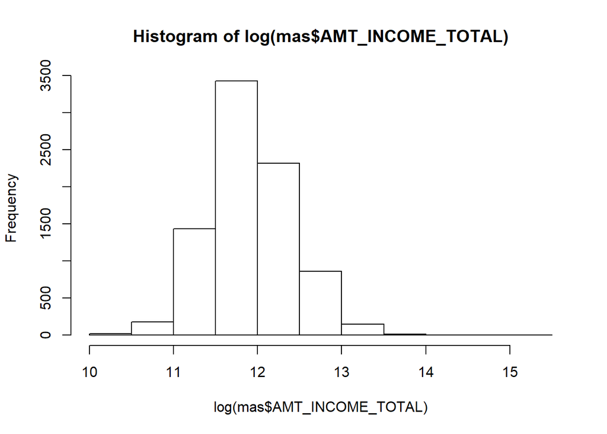

```r
hist(log(mas$AMT_INCOME_TOTAL))
```

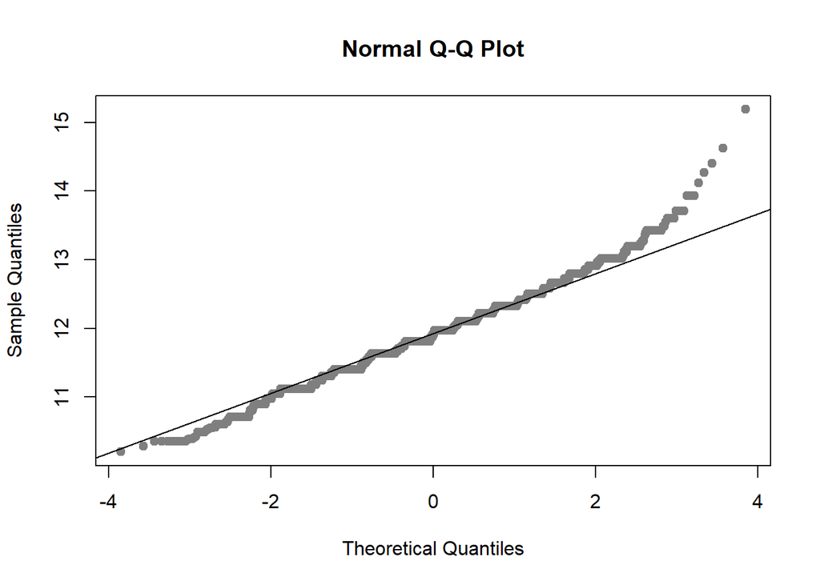

```r
qqnorm(log(mas$AMT_INCOME_TOTAL), pch = 19, col = "gray50")
qqline(log(mas$AMT_INCOME_TOTAL))
```

```r
lillie.test(log(t0$AMT_INCOME_TOTAL))
```

```
##
##  Lilliefors (Kolmogorov-Smirnov) normality test
##
## data:  log(t0$AMT_INCOME_TOTAL)
## D = 0.065467, p-value < 2.2e-16
```

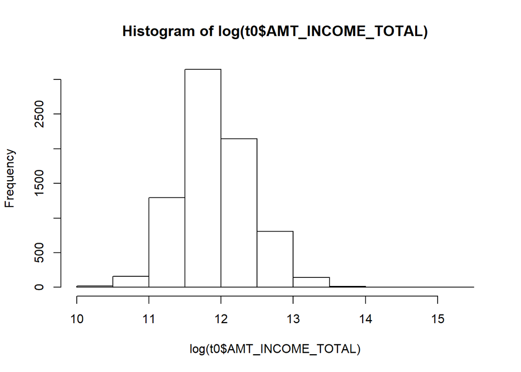

```r
hist(log(t0$AMT_INCOME_TOTAL))
```

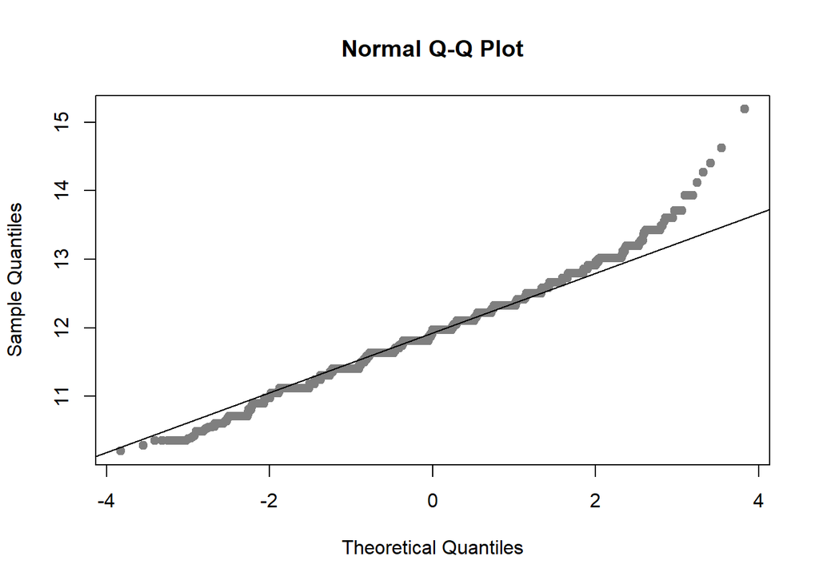

```r
qqnorm(log(t0$AMT_INCOME_TOTAL), pch = 19, col = "gray50")
qqline(log(t0$AMT_INCOME_TOTAL))
```

```r
lillie.test(log(t1$AMT_INCOME_TOTAL))
```

```
##
##  Lilliefors (Kolmogorov-Smirnov) normality test
##
## data:  log(t1$AMT_INCOME_TOTAL)
## D = 0.061236, p-value = 2.252e-06
```

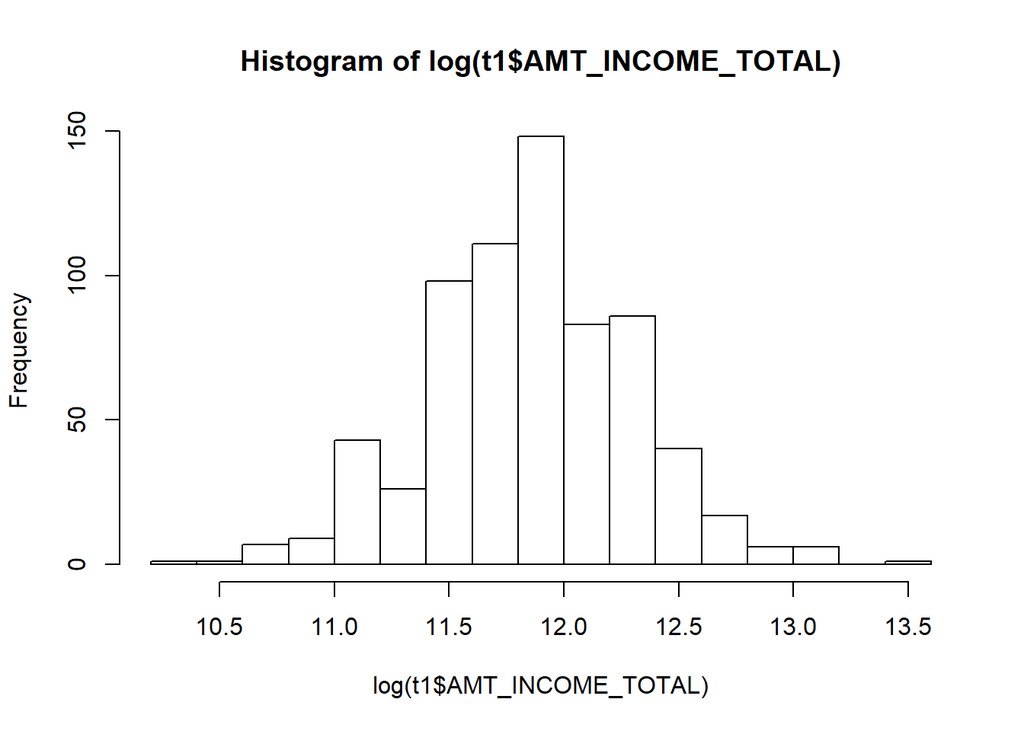

```r
hist(log(t1$AMT_INCOME_TOTAL))
```

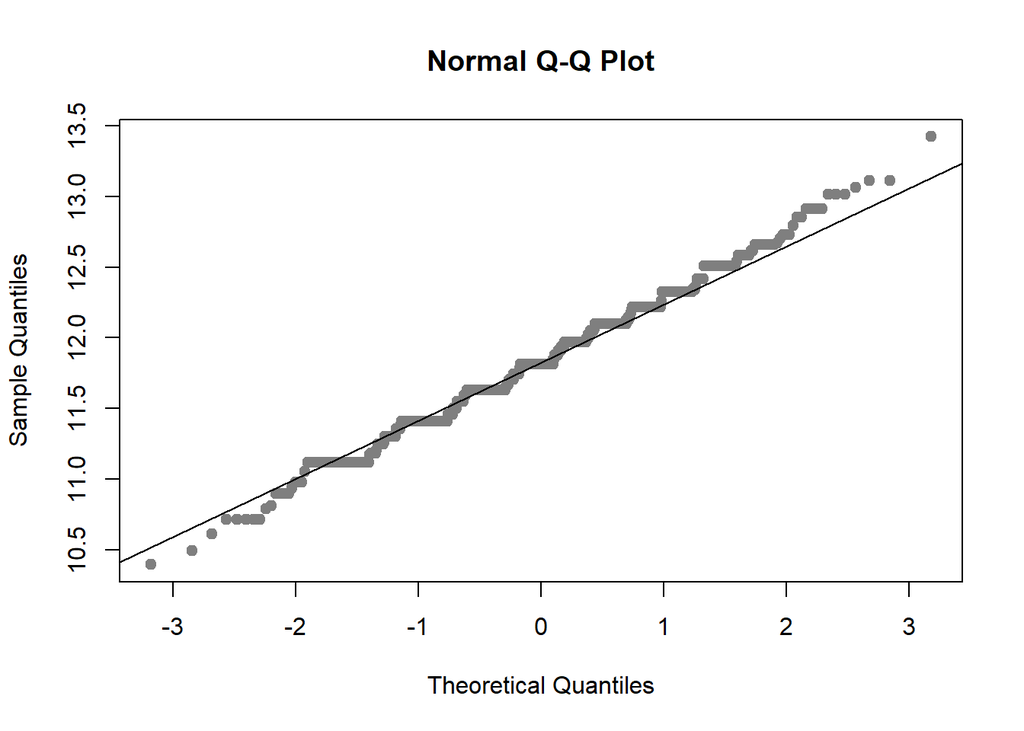

```r
qqnorm(log(t1$AMT_INCOME_TOTAL), pch = 19, col = "gray50")
qqline(log(t1$AMT_INCOME_TOTAL))
```

```r
ks.test(mas$DAYS_BIRTH, "pnorm", mean(mas$DAYS_BIRTH), sd(mas$AMT_CREDIT))
```

```
##
##  One-sample Kolmogorov-Smirnov test
##
## data:  mas$DAYS_BIRTH
## D = 0.49188, p-value < 2.2e-16
## alternative hypothesis: two-sided
```

Tras realizar el test de Smirnov y la modificacion del Lilliefors hemos visto que el contraste de normalidad nos devuelve un p-valor muy bajo (2.2e-16). Debido a estos resultados hemos probado a normalizar mediante el logaritmo con el mismo resultado. Al tratarse de un contraste tan delicado hemos usado metodos graficos para visualizar la normalidad. Tras comprobar los graficos y aplicar el teorema central del limite, debido al tamaño de nuestra muestra podriamos asumir que es normal.

## Ejercicio 9: Contraste de hipotesis para la comparacion de las muestras

```r
#muestra1 ---Target 0
#muestra2 ---Target 1

###analisis para Ingresos de la poblacion#####

#Ho: Igualdad de Medias en Ingresos para las muestras T0 y T1
#H1: No igualdad...

var.test(x = t0$AMT_INCOME_TOTAL, y = t1$AMT_INCOME_TOTAL )
```

```
##
##  F test to compare two variances
##
## data:  t0$AMT_INCOME_TOTAL and t1$AMT_INCOME_TOTAL
## F = 2.0628, num df = 7720, denom df = 682, p-value < 2.2e-16
## alternative hypothesis: true ratio of variances is not equal to 1
## 95 percent confidence interval:
##  1.841671 2.298552
## sample estimates:
## ratio of variances
##           2.062835
```

```r
test <- t.test(t0$AMT_INCOME_TOTAL,t1$AMT_INCOME_TOTAL) # Prueba t de Student
print(test)
```

```
##
##  Welch Two Sample t-test
##
## data:  t0$AMT_INCOME_TOTAL and t1$AMT_INCOME_TOTAL
## t = 5.4314, df = 950.81, p-value = 7.101e-08
## alternative hypothesis: true difference in means is not equal to 0
## 95 percent confidence interval:
##  10830.21 23083.88
## sample estimates:
## mean of x mean of y
##  170281.0  153323.9
```

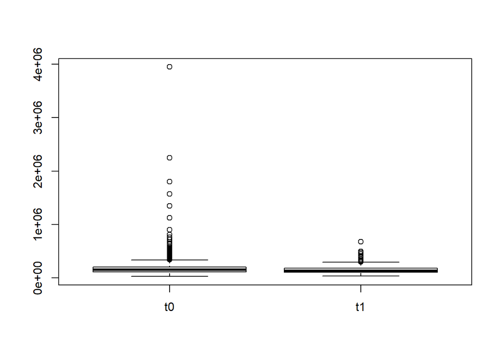

```r
# p-value es < 0.05 no podemos Rechazamos la Hipotesis Nula . El valor del estadístico t es muy pequeño
boxplot(t0$AMT_INCOME_TOTAL,t1$AMT_INCOME_TOTAL,names=c("t0","t1"))
```

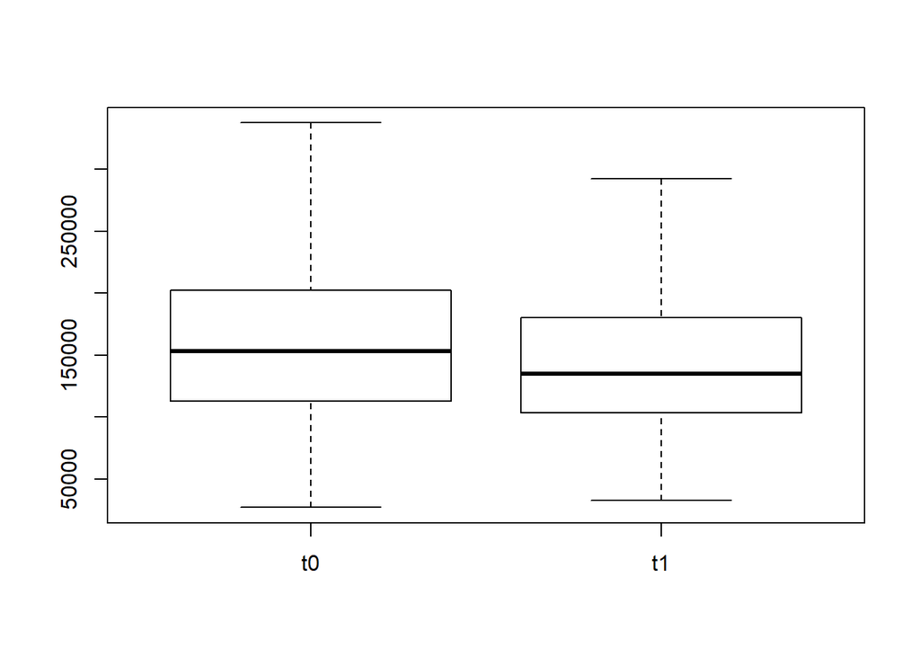

```r
#sin outliers parece que nos están mucho más próximos intuitivamente las medias#
##ESTUDIAR QUITAR LOS OUTLIER
boxplot(t0$AMT_INCOME_TOTAL,t1$AMT_INCOME_TOTAL,names=c("t0","t1"),outline=FALSE)
```

Realizamos el test de igualdad de medias. Rechazamos la hipotesis nula, lo que podemos decir es que a partir de nuestros datos muestrales y en nuestro caso de estudio, la media de los ingresos para la gente que paga o no paga es diferente. Intuitivamente lo podemos ver con el valor de 168977.2

Tambien nos apoyamos en esta afirmacion con los datos obtenidos en la grafica del boxplot. Nos da que pensar que si hiciesemos un trabajo con los outliars nuestro contraste de hipotesis podria variar.

El siguiente punto seria hacer un trabajo con los outliars y ver despues de este trabajo si el contraste de hipotesis funciona igual o no.